# Homework Assignment 1

Amir Salehzadeh (in collaboration with Sasha Kapur)

Assigned: Oct 24, 2020, Due Sun Nov 01, 2020 11:59PM

## Data basics and cleaning

```r
nyc <- read.csv("nycflights.csv")

#Quick exploration of data

str(nyc)
```

```
## 'data.frame':    336776 obs. of  20 variables:
##  $ X             : int  1 2 3 4 5 6 7 8 9 10 ...
##  $ year          : int  2013 2013 2013 2013 2013 2013 2013 2013 2013 2013 ...
##  $ month         : int  1 1 1 1 1 1 1 1 1 1 ...
##  $ day           : int  1 1 1 1 1 1 1 1 1 1 ...
##  $ dep_time      : int  517 533 542 544 554 554 555 557 557 558 ...
##  $ sched_dep_time: int  515 529 540 545 600 558 600 600 600 600 ...
##  $ dep_delay     : int  2 4 2 -1 -6 -4 -5 -3 -3 -2 ...
##  $ arr_time      : int  830 850 923 1004 812 740 913 709 838 753 ...
##  $ sched_arr_time: int  819 830 850 1022 837 728 854 723 846 745 ...
##  $ arr_delay     : int  11 20 33 -18 -25 12 19 -14 -8 8 ...
##  $ carrier       : chr  "UA" "UA" "AA" "B6" ...
##  $ flight        : int  1545 1714 1141 725 461 1696 507 5708 79 301 ...
##  $ tailnum       : chr  "N14228" "N24211" "N619AA" "N804JB" ...
##  $ origin        : chr  "EWR" "LGA" "JFK" "JFK" ...
##  $ dest          : chr  "IAH" "IAH" "MIA" "BQN" ...
##  $ air_time      : int  227 227 160 183 116 150 158 53 140 138 ...
##  $ distance      : int  1400 1416 1089 1576 762 719 1065 229 944 733 ...
##  $ hour          : int  5 5 5 5 6 5 6 6 6 6 ...
##  $ minute        : int  15 29 40 45 0 58 0 0 0 0 ...
##  $ time_hour     : chr  "2013-01-01 05:00:00" "2013-01-01 05:00:00" "2013-01-01 05:00:00" "2013-01-01 05:00:00" ...
```

```r
summary(nyc)
```

```
##        X               year          month             day
##  Min.   :     1   Min.   :2013   Min.   : 1.000   Min.   : 1.00
##  1st Qu.: 84195   1st Qu.:2013   1st Qu.: 4.000   1st Qu.: 8.00
##  Median :168388   Median :2013   Median : 7.000   Median :16.00
##  Mean   :168388   Mean   :2013   Mean   : 6.549   Mean   :15.71
##  3rd Qu.:252582   3rd Qu.:2013   3rd Qu.:10.000   3rd Qu.:23.00
##  Max.   :336776   Max.   :2013   Max.   :12.000   Max.   :31.00
##
##     dep_time    sched_dep_time   dep_delay          arr_time    sched_arr_time
##  Min.   :   1   Min.   : 106   Min.   : -43.00   Min.   :   1   Min.   :   1
##  1st Qu.: 907   1st Qu.: 906   1st Qu.:  -5.00   1st Qu.:1104   1st Qu.:1124
##  Median :1401   Median :1359   Median :  -2.00   Median :1535   Median :1556
##  Mean   :1349   Mean   :1344   Mean   :  12.64   Mean   :1502   Mean   :1536
##  3rd Qu.:1744   3rd Qu.:1729   3rd Qu.:  11.00   3rd Qu.:1940   3rd Qu.:1945
##  Max.   :2400   Max.   :2359   Max.   :1301.00   Max.   :2400   Max.   :2359
##  NA's   :8255                  NA's   :8255      NA's   :8713
##    arr_delay          carrier              flight       tailnum
##  Min.   : -86.000   Length:336776      Min.   :   1   Length:336776
##  1st Qu.: -17.000   Class :character   1st Qu.: 553   Class :character
##  Median :  -5.000   Mode  :character   Median :1496   Mode  :character
##  Mean   :   6.895                      Mean   :1972
##  3rd Qu.:  14.000                      3rd Qu.:3465
##  Max.   :1272.000                      Max.   :8500
##  NA's   :9430
##     origin              dest              air_time        distance
##  Length:336776      Length:336776      Min.   : 20.0   Min.   :  17
##  Class :character   Class :character   1st Qu.: 82.0   1st Qu.: 502
##  Mode  :character   Mode  :character   Median :129.0   Median : 872
##                                        Mean   :150.7   Mean   :1040
##                                        3rd Qu.:192.0   3rd Qu.:1389
##                                        Max.   :695.0   Max.   :4983
##                                        NA's   :9430
##       hour           minute       time_hour
##  Min.   : 1.00   Min.   : 0.00   Length:336776
##  1st Qu.: 9.00   1st Qu.: 8.00   Class :character
##  Median :13.00   Median :29.00   Mode  :character
##  Mean   :13.18   Mean   :26.23
##  3rd Qu.:17.00   3rd Qu.:44.00
##  Max.   :23.00   Max.   :59.00
##
```

```r
nyc$X<-NULL
nyc$origin <- as.factor(nyc$origin)
nyc$tailnum <- as.factor(nyc$tailnum)
nyc$month <- as.factor(nyc$month)
nyc$dest <- as.factor(nyc$dest)
nyc$carrier <- as.factor(nyc$carrier)
nyc$flight <- as.factor(nyc$flight)
```

## Data Exploration

- There are 16 airlines.

```r
#How many airlines are there
length(levels(nyc$carrier))
```

```
## [1] 16
```

- There are 32 flights with airline code ‘OO’

```r
#How many flights there were by the airline with code OO? (Hint: nrow can be useful here along with logical indexing)

length(which(nyc$carrier =='OO'))
```

```
## [1] 32
```

```r
#How long is the shortest flight out of any NYC airport? (Hint: `min` can be useful, remember to handle `NA` values)
min(nyc$distance, na.rm=TRUE)
```

```
## [1] 17
```

```r
summary(nyc$distance)
```

```
##    Min. 1st Qu.  Median    Mean 3rd Qu.    Max.
##      17     502     872    1040    1389    4983
```

- There were 112 United Airlines flights on Jan 12th, 2013.

```r
#How many flights where there by United Airlines (code: UA) on Jan 12th 2013?
nycUA <- nyc[nyc$carrier =="UA" & nyc$year=="2013" & nyc$month==1 & nyc$day ==12, ]
nrow(nycUA)
```

```
## [1] 112
```

## Arrival Delay

- The average arrival delay for all airports combined in Jan 2013 was 6.13 minutes.

```r
#What was the average arrival delay for all airports and all airlines combined in Jan 2013?
round(mean(nyc$arr_delay[nyc$month==1], na.rm=TRUE), 2)
```

```
## [1] 6.13
```

- The median arrival delay for all airports and airlines in Jan 2013 was -3 minutes.

```r
#Whats was the median arrival delay for all airports and all airlines combined in Jan 2013
summary(nyc$arr_delay[nyc$month==1])
```

```
##    Min. 1st Qu.  Median    Mean 3rd Qu.    Max.    NA's
##  -70.00  -15.00   -3.00    6.13   13.00 1272.00     606
```

- Median is negative which likely means that more flights arrive early than late.

## Airline Performance

- Average arrival delays by airline

```r
#Average arrival delay by airline
str(nyc$carrier)
```

```
##  Factor w/ 16 levels "9E","AA","AS",..: 12 12 2 4 5 12 4 6 4 2 ...
```

```r
meanDelayairlines <- tapply(nyc$arr_delay, nyc$carrier, mean, na.rm=TRUE)
str(meanDelayairlines)
```

```
##  num [1:16(1d)] 7.38 0.364 -9.931 9.458 1.644 ...
##  - attr(*, "dimnames")=List of 1
##   ..$ : chr [1:16] "9E" "AA" "AS" "B6" ...
```

```r
sort(round(meanDelayairlines, 1))
```

```
##   AS   HA   AA   DL   VX   US   UA   9E   B6   WN   MQ   OO   YV   EV   FL   F9
## -9.9 -6.9  0.4  1.6  1.8  2.1  3.6  7.4  9.5  9.6 10.8 11.9 15.6 15.8 20.1 21.9
```

```r
max(meanDelayairlines)
```

```
## [1] 21.9207
```

```r
min(meanDelayairlines)
```

```
## [1] -9.930889
```

```r
#order
meanDelayairlines <- meanDelayairlines[order(meanDelayairlines, decreasing =TRUE)]
round(meanDelayairlines,2)
```

```
##    F9    FL    EV    YV    OO    MQ    WN    B6    9E    UA    US    VX    DL
## 21.92 20.12 15.80 15.56 11.93 10.77  9.65  9.46  7.38  3.56  2.13  1.76  1.64
##    AA    HA    AS
##  0.36 -6.92 -9.93
```

- Bar Plot of Average Arrival Delays for all the Airlines

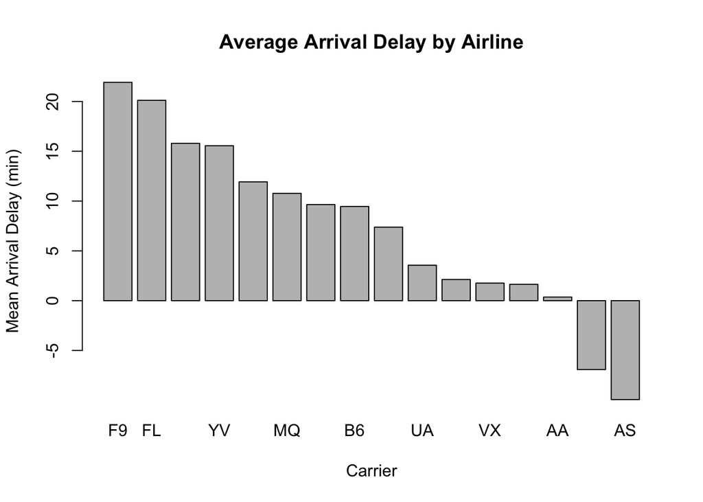

```r
#Draw a bar plot of average arrival delays for all the airlines
barplot(meanDelayairlines, xlab = "Carrier", ylab="Mean Arrival Delay (min)", main = "Average Arrival Delay by Airline")
```

- Airline `F9` has the highest average arrival delay (21.92 minutes). Airline `AS` has the smallest average arrival delay (-9.93 minutes), meaning `AS` flights arrive early, on average. `HA` also has a negative mean arrival delay. `AA` is the airline that has the smallest, positive average arrival delay (.36 minutes).

## Air Gain

1. Air gain is the difference between the departure delay and the arrival delay of a flight.

```r
#Create the column
nyc$airGain <- (nyc$dep_delay - nyc$arr_delay)
#Descriptive stats
str(nyc$airGain)
```

```
##  int [1:336776] -9 -16 -31 17 19 -16 -24 11 5 -10 ...
```

```r
summary(nyc$airGain)
```

```
##    Min. 1st Qu.  Median    Mean 3rd Qu.    Max.    NA's
## -196.00   -3.00    7.00    5.66   17.00  109.00    9430
```

```r
#Airgain by airline
meanAirGain <- tapply(nyc$airGain, nyc$carrier, mean, na.rm=TRUE)
str(meanAirGain)
```

```
##  num [1:16(1d)] 9.06 8.2 15.76 3.51 7.58 ...
##  - attr(*, "dimnames")=List of 1
##   ..$ : chr [1:16] "9E" "AA" "AS" "B6" ...
```

```r
meanAirGain<- sort(meanAirGain, decreasing=TRUE)
meanAirGain <- meanAirGain[order(meanAirGain, decreasing =TRUE)]
round(meanAirGain,2)
```

```
##    AS    HA    VX    9E    UA    AA    WN    DL    EV    B6    YV    US    OO
## 15.76 11.82 10.99  9.06  8.46  8.20  8.01  7.58  4.04  3.51  3.34  1.62  0.66
##    MQ    FL    F9
## -0.33 -1.51 -1.72
```

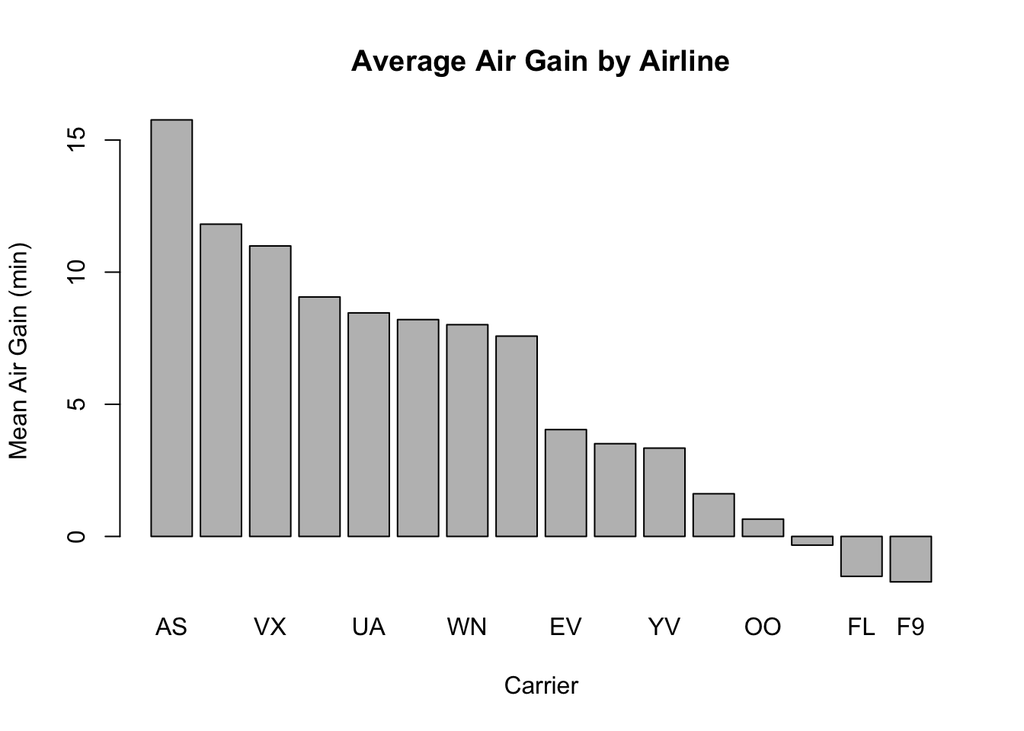

```r
#Barplot
barplot(meanAirGain, xlab = "Carrier", ylab="Mean Air Gain (min)", main = "Average Air Gain by Airline")
```

2. All of the listed airlines except for F9, FL, and MQ had positive mean airgains meaning that, on average, their flights gain time in air. Across all airlines, the mean airgain was 5.66 minutes. DL, WN, AA, UA, 9E, VX, HA, and AS all have higher than average airgain. Meanwhile, F9, FL, and MQ actually have a negative airgain and lose time in air.

## Merging Data Frames

1. Data cleaning

```r
planes <- read.csv("planes.csv")
str(planes)
```

```
## 'data.frame':    3322 obs. of  10 variables:
##  $ X           : int  1 2 3 4 5 6 7 8 9 10 ...
##  $ tailnum     : chr  "N10156" "N102UW" "N103US" "N104UW" ...
##  $ year        : int  2004 1998 1999 1999 2002 1999 1999 1999 1999 1999 ...
##  $ type        : chr  "Fixed wing multi engine" "Fixed wing multi engine" "Fixed wing multi engine" "Fixed wing multi engine" ...
##  $ manufacturer: chr  "EMBRAER" "AIRBUS INDUSTRIE" "AIRBUS INDUSTRIE" "AIRBUS INDUSTRIE" ...
##  $ model       : chr  "EMB-145XR" "A320-214" "A320-214" "A320-214" ...
##  $ engines     : int  2 2 2 2 2 2 2 2 2 2 ...
##  $ seats       : int  55 182 182 182 55 182 182 182 182 182 ...
##  $ speed       : int  NA NA NA NA NA NA NA NA NA NA ...
##  $ engine      : chr  "Turbo-fan" "Turbo-fan" "Turbo-fan" "Turbo-fan" ...
```

```r
planes$X <- NULL
planes$year <- as.factor(planes$year)
planes$type <- as.factor(planes$type)
planes$manufacturer <- as.factor(planes$manufacturer)
planes$engine <- as.factor(planes$engine)
```

2. Merging `nycflights` and `planes` data using the common column named `tailnum`.

```r
str(nyc)
```

```
## 'data.frame':    336776 obs. of  20 variables:
##  $ year          : int  2013 2013 2013 2013 2013 2013 2013 2013 2013 2013 ...
##  $ month         : Factor w/ 12 levels "1","2","3","4",..: 1 1 1 1 1 1 1 1 1 1 ...
##  $ day           : int  1 1 1 1 1 1 1 1 1 1 ...
##  $ dep_time      : int  517 533 542 544 554 554 555 557 557 558 ...
##  $ sched_dep_time: int  515 529 540 545 600 558 600 600 600 600 ...
##  $ dep_delay     : int  2 4 2 -1 -6 -4 -5 -3 -3 -2 ...
##  $ arr_time      : int  830 850 923 1004 812 740 913 709 838 753 ...
##  $ sched_arr_time: int  819 830 850 1022 837 728 854 723 846 745 ...
##  $ arr_delay     : int  11 20 33 -18 -25 12 19 -14 -8 8 ...
##  $ carrier       : Factor w/ 16 levels "9E","AA","AS",..: 12 12 2 4 5 12 4 6 4 2 ...
##  $ flight        : Factor w/ 3844 levels "1","2","3","4",..: 1382 1545 1042 677 425 1527 469 3700 69 266 ...
##  $ tailnum       : Factor w/ 4043 levels "D942DN","N0EGMQ",..: 180 524 2401 3204 2661 1142 1829 3300 2207 1178 ...
##  $ origin        : Factor w/ 3 levels "EWR","JFK","LGA": 1 3 2 2 3 1 1 3 2 3 ...
##  $ dest          : Factor w/ 105 levels "ABQ","ACK","ALB",..: 44 44 59 13 5 70 36 43 55 70 ...
##  $ air_time      : int  227 227 160 183 116 150 158 53 140 138 ...
##  $ distance      : int  1400 1416 1089 1576 762 719 1065 229 944 733 ...
##  $ hour          : int  5 5 5 5 6 5 6 6 6 6 ...
##  $ minute        : int  15 29 40 45 0 58 0 0 0 0 ...
##  $ time_hour     : chr  "2013-01-01 05:00:00" "2013-01-01 05:00:00" "2013-01-01 05:00:00" "2013-01-01 05:00:00" ...
##  $ airGain       : int  -9 -16 -31 17 19 -16 -24 11 5 -10 ...
```

```r
merged <- merge(nyc, planes, 'tailnum')
str(merged)
```

```
## 'data.frame':    284170 obs. of  28 variables:
##  $ tailnum       : Factor w/ 4043 levels "D942DN","N0EGMQ",..: 3 3 3 3 3 3 3 3 3 3 ...
##  $ year.x        : int  2013 2013 2013 2013 2013 2013 2013 2013 2013 2013 ...
##  $ month         : Factor w/ 12 levels "1","2","3","4",..: 8 1 1 1 2 9 3 3 11 6 ...
##  $ day           : int  12 17 23 10 17 23 12 20 3 11 ...
##  $ dep_time      : int  1312 1213 746 626 NA 1008 2000 2216 1218 1911 ...
##  $ sched_dep_time: int  1317 1218 645 630 1415 1015 2000 2100 1226 1911 ...
##  $ dep_delay     : int  -5 -5 61 -4 NA -7 0 76 -8 0 ...
##  $ arr_time      : int  1528 1422 852 802 NA 1117 2234 13 1404 2124 ...
##  $ sched_arr_time: int  1528 1415 757 800 1616 1139 2245 2315 1418 2115 ...
##  $ arr_delay     : int  0 7 55 2 NA -22 -11 58 -14 9 ...
##  $ carrier       : Factor w/ 16 levels "9E","AA","AS",..: 6 6 6 6 6 6 6 6 6 6 ...
##  $ flight        : Factor w/ 3844 levels "1","2","3","4",..: 2973 3253 2916 3186 2905 2864 2881 2628 3252 3052 ...
##  $ origin        : Factor w/ 3 levels "EWR","JFK","LGA": 1 1 1 1 1 1 1 1 1 1 ...
##  $ dest          : Factor w/ 105 levels "ABQ","ACK","ALB",..: 63 24 29 76 22 11 68 89 28 54 ...
##  $ air_time      : int  171 111 47 60 NA 105 193 101 92 157 ...
##  $ distance      : int  1167 529 199 319 628 748 1325 642 533 1092 ...
##  $ hour          : int  13 12 6 6 14 10 20 21 12 19 ...
##  $ minute        : int  17 18 45 30 15 15 0 0 26 11 ...
##  $ time_hour     : chr  "2013-08-12 13:00:00" "2013-01-17 12:00:00" "2013-01-23 06:00:00" "2013-01-10 06:00:00" ...
##  $ airGain       : int  -5 -12 6 -6 NA 15 11 18 6 -9 ...
##  $ year.y        : Factor w/ 46 levels "1956","1959",..: 37 37 37 37 37 37 37 37 37 37 ...
##  $ type          : Factor w/ 3 levels "Fixed wing multi engine",..: 1 1 1 1 1 1 1 1 1 1 ...
##  $ manufacturer  : Factor w/ 35 levels "AGUSTA SPA","AIRBUS",..: 18 18 18 18 18 18 18 18 18 18 ...
##  $ model         : chr  "EMB-145XR" "EMB-145XR" "EMB-145XR" "EMB-145XR" ...
##  $ engines       : int  2 2 2 2 2 2 2 2 2 2 ...
##  $ seats         : int  55 55 55 55 55 55 55 55 55 55 ...
##  $ speed         : int  NA NA NA NA NA NA NA NA NA NA ...
##  $ engine        : Factor w/ 6 levels "4 Cycle","Reciprocating",..: 3 3 3 3 3 3 3 3 3 3 ...
```

3. Pose five interesting questions and answer them.

### Q1

**1. What is the best engine type for cross-country flights (or longer)?** To judge the “best” engine type, I measured arrival delay (as a passenger, that’s what I care most about). Thus, the flights with the lowest arrival delay have the “best” engine in my opinion. First, I created a subset of the merged dataset, which only included flights of 3000 miles or more. There were 711 cross-country or longer flights, and about half of them use turbo-fan engines and the other ~half use turbo-jet engines. Then, I created a barplot to show the average arrival delay by the engine type. In summary, the flights using turbo-jet engines had a 3.77 minute mean delay, whereas the flights using turbo-fan engines had a -6.92 minute delay. This data suggests that turbo-fan engines are the best choice for cross-country flights, if the metric of success is arrival delay.

```r
#Create a sample with only 'long' flights (3000 miles or more)
longFlights <- merged[merged$distance>=3000, ]
nrow(longFlights)
```

```
## [1] 711
```

```r
summary(longFlights$distance)
```

```
##    Min. 1st Qu.  Median    Mean 3rd Qu.    Max.
##    3370    4963    4963    4959    4983    4983
```

```r
summary(longFlights$engine)
```

```
##       4 Cycle Reciprocating     Turbo-fan     Turbo-jet    Turbo-prop
##             0             0           342           369             0
##   Turbo-shaft
##             0
```

```r
str(longFlights)
```

```
## 'data.frame':    711 obs. of  28 variables:
##  $ tailnum       : Factor w/ 4043 levels "D942DN","N0EGMQ",..: 1070 1070 1070 1070 1070 1070 1070 1070 1070 1070 ...
##  $ year.x        : int  2013 2013 2013 2013 2013 2013 2013 2013 2013 2013 ...
##  $ month         : Factor w/ 12 levels "1","2","3","4",..: 4 3 10 1 1 11 9 12 2 11 ...
##  $ day           : int  12 29 4 3 2 2 7 22 28 6 ...
##  $ dep_time      : int  957 955 954 914 909 950 953 925 924 951 ...
##  $ sched_dep_time: int  1000 1000 1000 900 900 1000 1000 930 900 1000 ...
##  $ dep_delay     : int  -3 -5 -6 14 9 -10 -7 -5 24 -9 ...
##  $ arr_time      : int  1444 1432 1438 1504 1525 1457 1407 1517 1455 1609 ...
##  $ sched_arr_time: int  1510 1530 1450 1530 1530 1450 1445 1535 1540 1555 ...
##  $ arr_delay     : int  -26 -58 -12 -26 -5 7 -38 -18 -45 14 ...
##  $ carrier       : Factor w/ 16 levels "9E","AA","AS",..: 9 9 9 9 9 9 9 9 9 9 ...
##  $ flight        : Factor w/ 3844 levels "1","2","3","4",..: 46 46 46 46 46 46 46 46 46 46 ...
##  $ origin        : Factor w/ 3 levels "EWR","JFK","LGA": 2 2 2 2 2 2 2 2 2 2 ...
##  $ dest          : Factor w/ 105 levels "ABQ","ACK","ALB",..: 41 41 41 41 41 41 41 41 41 41 ...
##  $ air_time      : int  608 617 618 616 638 632 593 620 612 659 ...
##  $ distance      : int  4983 4983 4983 4983 4983 4983 4983 4983 4983 4983 ...
##  $ hour          : int  10 10 10 9 9 10 10 9 9 10 ...
##  $ minute        : int  0 0 0 0 0 0 0 30 0 0 ...
##  $ time_hour     : chr  "2013-04-12 10:00:00" "2013-03-29 10:00:00" "2013-10-04 10:00:00" "2013-01-03 09:00:00" ...
##  $ airGain       : int  23 53 6 40 14 -17 31 13 69 -23 ...
##  $ year.y        : Factor w/ 46 levels "1956","1959",..: 43 43 43 43 43 43 43 43 43 43 ...
##  $ type          : Factor w/ 3 levels "Fixed wing multi engine",..: 1 1 1 1 1 1 1 1 1 1 ...
##  $ manufacturer  : Factor w/ 35 levels "AGUSTA SPA","AIRBUS",..: 2 2 2 2 2 2 2 2 2 2 ...
##  $ model         : chr  "A330-243" "A330-243" "A330-243" "A330-243" ...
##  $ engines       : int  2 2 2 2 2 2 2 2 2 2 ...
##  $ seats         : int  377 377 377 377 377 377 377 377 377 377 ...
##  $ speed         : int  NA NA NA NA NA NA NA NA NA NA ...
##  $ engine        : Factor w/ 6 levels "4 Cycle","Reciprocating",..: 3 3 3 3 3 3 3 3 3 3 ...
```

```r
meanDelay <- tapply(longFlights$arr_delay, longFlights$engine, mean, na.rm=TRUE)
meanDelay<- round(meanDelay[order(meanDelay, decreasing=TRUE)], 2)
meanDelay
```

```
##     Turbo-jet     Turbo-fan       4 Cycle Reciprocating    Turbo-prop
##          3.77         -6.92            NA            NA            NA
##   Turbo-shaft
##            NA
```

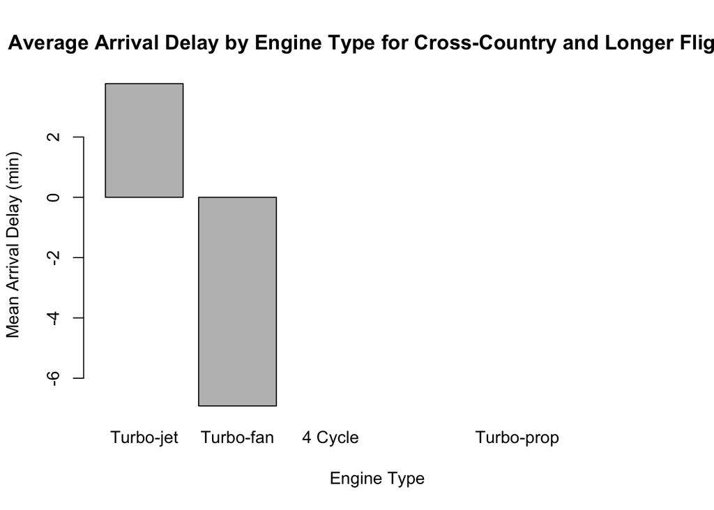

```r
#Barplot
barplot(meanDelay, xlab = "Engine Type", ylab="Mean Arrival Delay (min)", main = "Average Arrival Delay by Engine Type for Cross-Country and Longer Flights")
```

### Q2

**2. What time of day is best for traveling from NYC to DTW?** Morning flights from LGA to DTW are the best, with an average arrival surplus of -8.

```r
#Create and populate a flight time of day column
merged$flightTime <- 'unassigned'
merged$flightTime <- ifelse(is.na(merged$sched_dep_time), 'NA',
                         ifelse(merged$sched_dep_time>=2000, 'night',
                                ifelse(merged$sched_dep_time>=1600, 'evening',
                                ifelse(merged$sched_dep_time>=1200, 'afternoon',
                                       ifelse(merged$sched_dep_time>=400, 'morning',
                                       'night')))))
merged$flightTime <-as.factor(merged$flightTime)
summary(merged$flightTime)
```

```
## afternoon   evening   morning     night
##     69102     75356    111606     28106
```

```r
#choose the subset of flights with destination "DTW"
nycDTW <- merged[merged$dest=='DTW',]

#get mean arrival delay by time of day
#barplot of arrival delay by flight time, ideally broken down aka stacked by origin
aggregate(arr_delay ~ flightTime, data=nycDTW, mean)
```

```
##   flightTime arr_delay
## 1  afternoon  8.610840
## 2    evening 16.410522
## 3    morning -3.988506
## 4      night 20.223301
```

```r
flightDelay.Time <- aggregate(arr_delay ~ flightTime, data=nycDTW, mean)
flightDelay.Time <- flightDelay.Time[order(flightDelay.Time$arr_delay),]
flightDelay.Time[1,]
```

```
##   flightTime arr_delay
## 3    morning -3.988506
```

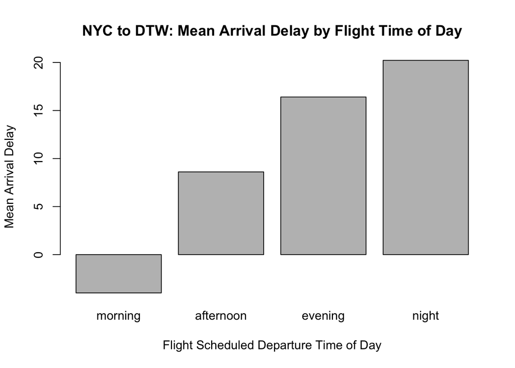

```r
barplot(flightDelay.Time$arr_delay, axes=TRUE, xlab="Flight Scheduled Departure Time of Day", ylab="Mean Arrival Delay", main="NYC to DTW: Mean Arrival Delay by Flight Time of Day", names.arg=c("morning", "afternoon", "evening", "night"))
```

```r
aggregate(arr_delay ~ origin + flightTime, data=nycDTW, mean)
```

```
##    origin flightTime  arr_delay
## 1     EWR  afternoon 15.0417790
## 2     JFK  afternoon  1.8895028
## 3     LGA  afternoon  3.6662031
## 4     EWR    evening 26.9703504
## 5     JFK    evening 12.4829352
## 6     LGA    evening 10.8264379
## 7     EWR    morning  0.1535211
## 8     JFK    morning -4.0749280
## 9     LGA    morning -8.0185950
## 10    EWR      night 21.8472222
## 11    LGA      night 16.4516129
```

```r
flightDelay.Time.Origin <- aggregate(arr_delay ~ origin + flightTime, data=nycDTW, mean)
flightDelay.Time.Origin <- flightDelay.Time.Origin[order(flightDelay.Time.Origin$arr_delay),]
flightDelay.Time.Origin[1,]
```

```
##   origin flightTime arr_delay
## 9    LGA    morning -8.018595
```